# Final Project: -Display Advertising Challenge

Team 25: Michael Zeng, Param Viswanathan, Gopinath Duddi, Hailey Wu

# Question Formulation

- The goal of this project is to predict the click-through rate on the advertising based on a variety of features collected.
- The empirical relationship between the observablem features and the efficiency of the advertisement distribution that this research is trying to establish will be extremely valuable to a lot of businesses.

There are unique challenges to this problem:

1. The sheer size of the data makes it unsuitable for the typical tools people use for modeling, such as Pandas and SKlearn, which is why we choose to do it with Spark MLlib.
2. The complexity of the features space would normally require a lot of domain knowledge, yet here the data is presented anonymously. Therefore, the research presented in this notebook will be based on statistical observations and practices.
3. While researching into the problem, our team also keeps in mind the needs of real-time production. And that's why we have built Spark pipelines for the data, and depending on the business needs, we could efficiently deploy the code for updates/retrain of the model.

Yet, such unique problem setup also has certain benefits:

1. The data is not so imbalanced, which makes it suitable for a larger set of algorithms had it been imbalanced such as problem of predicting credit card default.
2. The lack of timestamps also frees us from considerations of time series property of our model and its predictions.
3. The problem itself allows bigger margin of error and is not so demanding on the intuitiveness of the model. Meaning the business wouldn't really grill us if we got one or two predictions wrong, nor are they likely to demand that we "open the box" for them and explain exactly what went into the prediction on any given case. This also opens up more freedom for us in terms of features engineering and model selection.

# Algorithm explanation

In this section, we try to implement logistic regression using RDD with the sampled data (`sample_df`). To make the calculation easier, we picked the first numeric column `c01`, a categorical column `b09` with the least number of unique categories, and the top 100 rows to form a toy RDD dataset.

- Logistic Regression
  - Setup: $$p(y = 1) = \frac{1}{1+exp(-wX)}$$
  - Objective function: $$L = \frac{1}{m}\sum_{i=1}^m y_i\cdot log(p(y_i = 1))+ (1-y_i)\cdot log(1- p(y_i = 1))$$
  - Gradient:$$J = \frac{1}{m} \sum_{i=1}^m (y_i-p(y_i = 1))x_i$$

```python
# head of sample_df_toy
sample_df_toy = sample_df.select("c01", "b09", "label").limit(100)
sample_df_toy.show(5)
```

```
+---+--------+-----+
|c01|     b09|label|
+---+--------+-----+
|0.0|a73ee510|    0|
|0.0|a73ee510|    0|
|0.0|a73ee510|    0|
|1.0|a73ee510|    0|
|0.0|a73ee510|    1|
+---+--------+-----+
only showing top 5 rows
```

```python
# distribution of labels, it is close to the full dataset
sample_df_toy.groupBy('label').count().show()
```

```
+-----+-----+
|label|count|
+-----+-----+
|    0|   73|
|    1|   27|
+-----+-----+
```

- Transform the continuous variable with log1p:

```python
# the original disttribution is skewed, but since it is non-negative, log1p is a suitable transformation
sample_df_toy.select('c01').describe().toPandas().transpose()
```

|  | 0 | 1 | 2 | 3 | 4 |
| --- | --- | --- | --- | --- | --- |
| summary | count | mean | stddev | min | max |
| c01 | 100 | 1.56 | 4.23148372860567 | 0.0 | 25.0 |

```python
# log1p transoformation, after which the scales are more compact.
from pyspark.sql.functions import when, log1p, col
sample_df_toy = sample_df_toy.withColumn('c01_t', log1p('c01'))
sample_df_toy.show(5)
sample_df_toy.select('c01_t').describe().toPandas().transpose()
```

```
+---+--------+-----+------------------+
|c01|     b09|label|             c01_t|
+---+--------+-----+------------------+
|0.0|a73ee510|    0|               0.0|
|0.0|a73ee510|    0|               0.0|
|0.0|a73ee510|    0|               0.0|
|1.0|a73ee510|    0|0.6931471805599453|
|0.0|a73ee510|    1|               0.0|
+---+--------+-----+------------------+
only showing top 5 rows
```

|  | 0 | 1 | 2 | 3 | 4 |
| --- | --- | --- | --- | --- | --- |
| summary | count | mean | stddev | min | max |
| c01_t | 100 | 0.429320903037294 | 0.8011288879342549 | 0.0 | 3.258096538021482 |

- Standardize the transformed c01:

```python
# we'd de-mean and devide by standard deviation
# after that the column is mean 0 with stdev 1
sample_df_toy = sample_df_toy.withColumn('c01_ts', (col('c01_t') - 0.429320903037294)/0.8011288879342549)
sample_df_toy.show(5)
sample_df_toy.select('c01_ts').describe().toPandas().transpose()
```

```
+---+--------+-----+------------------+------------------+
|c01|     b09|label|             c01_t|            c01_ts|
+---+--------+-----+------------------+------------------+
|0.0|a73ee510|    0|               0.0|-0.535894922157053|
|0.0|a73ee510|    0|               0.0|-0.535894922157053|
|0.0|a73ee510|    0|               0.0|-0.535894922157053|
|1.0|a73ee510|    0|0.6931471805599453|0.3293181428058832|
|0.0|a73ee510|    1|               0.0|-0.535894922157053|
+---+--------+-----+------------------+------------------+
only showing top 5 rows
```

|  | 0 | 1 | 2 | 3 | 4 |
| --- | --- | --- | --- | --- | --- |
| summary | count | mean | stddev | min | max |
| c01_ts | 100 | 7.549516567451065E-17 | 1.0 | -0.535894922157053 | 3.5309869330493218 |

- One-hot Encode the categorical variable: here we only have two categories which makes it a lot easier.

```python
# there are two categories originally
sample_df_toy.groupBy('b09').count().show()
```

```
+--------+-----+
|     b09|count|
+--------+-----+
|a73ee510|   90|
|7cc72ec2|   10|
+--------+-----+
```

```python
# one-hot encoding
sample_df_toy = sample_df_toy.withColumn('b09_t1', when(col('b09') == 'a73ee510', 1).otherwise(0))
sample_df_toy.show(10)
```

```
+---+--------+-----+------------------+------------------+------+
|c01|     b09|label|             c01_t|            c01_ts|b09_t1|
+---+--------+-----+------------------+------------------+------+
|0.0|a73ee510|    0|               0.0|-0.535894922157053|     1|
|0.0|a73ee510|    0|               0.0|-0.535894922157053|     1|
|0.0|a73ee510|    0|               0.0|-0.535894922157053|     1|
|1.0|a73ee510|    0|0.6931471805599453|0.3293181428058832|     1|
|0.0|a73ee510|    1|               0.0|-0.535894922157053|     1|
|3.0|a73ee510|    1|1.3862943611198906|1.1945312077688193|     1|
|0.0|a73ee510|    0|               0.0|-0.535894922157053|     1|
|0.0|a73ee510|    0|               0.0|-0.535894922157053|     1|
|0.0|a73ee510|    0|               0.0|-0.535894922157053|     1|
|0.0|7cc72ec2|    0|               0.0|-0.535894922157053|     0|
+---+--------+-----+------------------+------------------+------+
only showing top 10 rows
```

Now implement the gradient descend and logistic regression using RDD. The code largely leveraged the code for linear regression in HW4.

```
BASELINE:  Loss = 0.6931471805599451
BASELINE:  Model = [0 0 0]
showing the first 5 steps in print, the rest in chart
----------
STEP: 1
Loss: 0.6547251711209194
Model: [-0.092, 0.05, -0.076]
----------
STEP: 2
Loss: 0.6280398732611083
Model: [-0.168, 0.096, -0.137]
----------
STEP: 3
Loss: 0.6092471394084692
Model: [-0.231, 0.138, -0.186]
----------
STEP: 4
Loss: 0.5957889561966307
Model: [-0.284, 0.176, -0.226]
----------
STEP: 5
Loss: 0.5859803799941462
Model: [-0.328, 0.211, -0.259]
Final model: Model = [-0.87190886  0.58637348 -0.15645926]
```

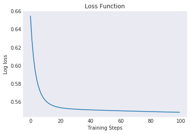

```python
# training process

nSteps = 100
# append 0s for intercept
model = np.append([0], np.repeat(0, 2))
print(f"BASELINE:  Loss = {Loss(sample_df_toy_rdd,model)}")
print(f"BASELINE:  Model = {model}")
trace = []
print("showing the first 5 steps in print, the rest in chart")

for idx in range(nSteps):
    model = GDUpdate(sample_df_toy_rdd, model)
    loss = Loss(sample_df_toy_rdd, model)
    if (idx < 5):
        # show only the 5 steps
        print("----------")
        print(f"STEP: {idx+1}")
        print(f"Loss: {loss}")
        print(f"Model: {[round(w,3) for w in model]}")
    trace = np.append(trace, [loss])

g = sns.lineplot(x=range(nSteps), y=trace)
g.set_title('Loss Function')
g.set_xlabel('Training Steps')
g.set_ylabel('Log loss')

print(f'Final model: Model = {model}')

# Getting prediction
pred = sample_df_toy_rdd.map(lambda x: (np.append([1.0], x[0]), x[1]))\
                        .map(lambda x: 1 * (1/(1 + np.exp(- np.dot(model, x[0]))) > 0.5))\
                        .collect()
```

- Just to verify our results with a standard implementation from SKlearn:

```python
# compare coef and f1-score
from sklearn.linear_model import LogisticRegression
from sklearn.metrics import f1_score
sample_df_toy_pandas = sample_df_toy.select('c01_ts', 'b09_t1', 'label').toPandas()
skl_model = LogisticRegression(fit_intercept=True)
skl_model.fit(sample_df_toy_pandas[['c01_ts', 'b09_t1']], sample_df_toy_pandas['label'])
print(f'SKLearn logistic model weights: {np.append(skl_model.intercept_, skl_model.coef_)}')
print(f'Self-implemented model weights: {model}')
skl_pred = skl_model.predict(sample_df_toy_pandas[['c01_ts', 'b09_t1']])
print(f'SKLearn logistic model f1-score: {round(f1_score(y_pred=skl_pred, y_true=sample_df_toy_pandas.label), 3)}')
print(f'Self-implemented model f1-score: {round(f1_score(y_pred = pred, y_true = sample_df_toy_pandas.label), 3)}')
```

```
SKLearn logistic model weights: [-1.03740904  0.5448784   0.05474129]
Self-implemented model weights: [-0.87190886  0.58637348 -0.15645926]
SKLearn logistic model f1-score: 0.333
Self-implemented model f1-score: 0.333
```

```
Text(0,0.5,'Sklearn')
```

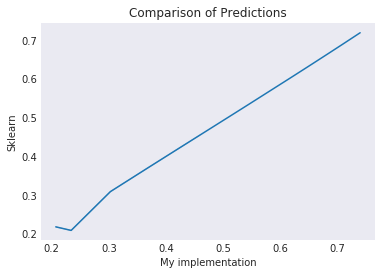

```python
# compare predictions
pred_prob = sample_df_toy_rdd.map(lambda x: (np.append([1.0], x[0]), x[1]))\
                    .map(lambda x: (1/(1 + np.exp(- np.dot(model, x[0])))))\
                    .collect()
g = sns.lineplot(x=pred_prob,
                 y=[x[1] for x in skl_model.predict_proba(sample_df_toy_pandas[['c01_ts', 'b09_t1']])])
g.set_title('Comparison of Predictions')
g.set_xlabel('My implementation')
g.set_ylabel('Sklearn')
```

- Observations:
  - the model coefficients are slightly off because we are only looking at numerical solutions for logistic regression, which also depends on initialization, learning rate, number of steps and a variety of parameters.
  - despite of that, the probability predictions are quite similar between the two implementations, which shows that our algorithm at least get most of the things correct;
  - the f1 score is exactly the same is quite coincidental given that we only have 100 data points in this toy training set.

# EDA & Discussion of Challenges

- categorical features
- numerical features
- discussion of challenges

## Categorical Features

- There are 26 categorical features in the data set, but each will have varying number of categories that is hashed.

```python
categorical_features = [t[0] for t in sample_df.dtypes if t[1] == 'string']
categorical_features
```

```
['b01',
 'b02',
 'b03',
 'b04',
 'b05',
 'b06',
 'b07',
 'b08',
 'b09',
 'b10',
 'b11',
 'b12',
 'b13',
 'b14',
 'b15',
 'b16',
 'b17',
 'b18',
 'b19',
 'b20',
 'b21',
 'b22',
 'b23',
 'b24',
 'b25',
 'b26']
```

- The first things we want to explore with the categorical features is the number of unique categories in each one of them.

```python
features_summary
```

|  | name | # unique | # empty | # count = 1 | # count < 10 | # count < 100 | # count < 1000 |
| --- | --- | --- | --- | --- | --- | --- | --- |
| 25 | b01 | 536 | 0 | 255 | 432 | 505 | 527 |
| 24 | b02 | 518 | 0 | 30 | 140 | 381 | 499 |
| 23 | b03 | 46692 | 3408 | 41673 | 45968 | 46621 | 46689 |
| 22 | b04 | 25550 | 3408 | 19263 | 24565 | 25453 | 25543 |
| 21 | b05 | 143 | 0 | 55 | 104 | 127 | 137 |
| 20 | b06 | 12 | 12025 | 2 | 4 | 5 | 5 |
| 19 | b07 | 8042 | 0 | 1985 | 6003 | 7901 | 8040 |
| 18 | b08 | 235 | 0 | 87 | 173 | 214 | 228 |
| 17 | b09 | 3 | 0 | 0 | 0 | 1 | 1 |
| 16 | b10 | 12032 | 0 | 5848 | 10592 | 11948 | 12030 |
| 15 | b11 | 3965 | 0 | 645 | 2303 | 3786 | 3960 |
| 14 | b12 | 42896 | 3408 | 37748 | 42145 | 42819 | 42892 |
| 13 | b13 | 2912 | 0 | 277 | 1441 | 2719 | 2905 |
| 12 | b14 | 26 | 0 | 0 | 3 | 11 | 18 |
| 11 | b15 | 5333 | 0 | 1741 | 3939 | 5133 | 5331 |
| 10 | b16 | 35834 | 3408 | 30232 | 34981 | 35745 | 35830 |
| 9 | b17 | 9 | 0 | 0 | 0 | 0 | 0 |
| 8 | b18 | 2605 | 0 | 677 | 1717 | 2408 | 2595 |
| 7 | b19 | 1295 | 43810 | 346 | 964 | 1254 | 1292 |
| 6 | b20 | 4 | 43810 | 0 | 0 | 0 | 0 |
| 5 | b21 | 39920 | 3408 | 34598 | 39144 | 39836 | 39916 |
| 4 | b22 | 10 | 76163 | 0 | 1 | 4 | 7 |
| 3 | b23 | 15 | 0 | 1 | 1 | 3 | 7 |
| 2 | b24 | 12185 | 3408 | 7414 | 11240 | 12091 | 12172 |
| 1 | b25 | 52 | 43810 | 6 | 16 | 30 | 42 |
| 0 | b26 | 9291 | 43810 | 5637 | 8574 | 9235 | 9284 |

- A few observations from the analysis above:
  - columns `b03`, `b04`, `b12`, `b16`, `b21`, `b24` all have 3408 empty strings; columns `b19`, `b20`, `b25` and `b26` all have 43810 empty strings. And therefore, these columns might be related.
  - the distribution of categories are very skewed: for example, column `b04` has 25k unique categories, but 19K of them only have 1 occurances. Based on this observation, we could impute the categories with less than 1000 (which is 1% of the sample) count with some string, which will help reduce the number of unique categories.

After the imputation, the features summary goes as follows:

```python
features_summary
```

|  | name | # unique before | # unique after | larger_than_1pc |
| --- | --- | --- | --- | --- |
| 25 | b01 | 536 | 10 | [5a9ed9b0, 05db9164, 8cf07265, 68fd1e64, 87552... |
| 24 | b02 | 518 | 20 | [80e26c9b, 58e67aaf, 38a947a1, 09e68b86, 28713... |
| 23 | b03 | 46692 | 4 | [empty_1, d032c263, 02cf9876] |
| 22 | b04 | 25550 | 8 | [d16679b9, empty_0, c18be181, 85dd697c, f922ef... |
| 21 | b05 | 143 | 7 | [4cf72387, 25c83c98, 43b19349, 30903e74, 38487... |
| 20 | b06 | 12 | 8 | [empty_0, 7e0ccccf, fbad5c96, 6f6d9be8, fe6b92... |
| 19 | b07 | 8042 | 3 | [1c86e0eb, dc7659bd] |
| 18 | b08 | 235 | 8 | [0b153874, 5b392875, 1f89b562, 37e4aa92, 062b5... |
| 17 | b09 | 3 | 3 | [a73ee510, 7cc72ec2] |
| 16 | b10 | 12032 | 3 | [3b08e48b, efea433b] |
| 15 | b11 | 3965 | 6 | [8b94178b, 755e4a50, e51ddf94, 4d8549da, 7f8ff... |
| 14 | b12 | 42896 | 5 | [empty_1, dfbb09fb, 8fe001f4, 6aaba33c] |
| 13 | b13 | 2912 | 8 | [025225f2, 5978055e, 3516f6e6, 1aa94af3, 740c2... |
| 12 | b14 | 26 | 9 | [b28479f6, 1adce6ef, 07d13a8f, cfef1c29, 64c94... |
| 11 | b15 | 5333 | 3 | [d345b1a0, 2d0bb053] |
| 10 | b16 | 35834 | 5 | [empty_1, 84898b2a, 36103458, b041b04a] |
| 9 | b17 | 9 | 9 | [1e88c74f, e5ba7672, d4bb7bd8, 776ce399, 2005a... |
| 8 | b18 | 2605 | 11 | [c21c3e4c, 5aed7436, 891589e7, e88ffc9d, 5bb2e... |
| 7 | b19 | 1295 | 4 | [21ddcdc9, empty_2, 55dd3565] |
| 6 | b20 | 4 | 4 | [5840adea, empty_2, b1252a9d, a458ea53] |
| 5 | b21 | 39920 | 5 | [empty_1, 0014c32a, e587c466, 723b4dfd] |
| 4 | b22 | 10 | 4 | [empty_0, c9d4222a, ad3062eb] |
| 3 | b23 | 15 | 9 | [32c7478e, bcdee96c, 3a171ecb, 423fab69, 55dd3... |
| 2 | b24 | 12185 | 14 | [aee52b6f, 3fdb382b, empty_1, ded4aac9, 3b183c... |
| 1 | b25 | 52 | 11 | [e8b83407, empty_2, 9b3e8820, 2bf691b1, ea9a24... |
| 0 | b26 | 9291 | 8 | [empty_2, 984e0db0, 49d68486, aa5f0a15, c84c4a... |

- For now, we select all the categorical variables for building the models. Based on the insights of the models we tested, we'd make further selections on the categorical features.

```python
categorical_features_select = categorical_features
```

## Numerical Features

- first thing we did is to print out the sumamry of the numerical features: the average, the standard deviation, the minimum and maximum.

```python
numeric_features = [t[0] for t in sample_df.dtypes if t[1] == 'double']
sample_df.select(numeric_features).describe().toPandas().transpose()
```

|  | 0 | 1 | 2 | 3 | 4 |
| --- | --- | --- | --- | --- | --- |
| summary | count | mean | stddev | min | max |
| c01 | 100085 | 1.9143927661487736 | 7.963545316430234 | 0.0 | 1262.0 |
| c02 | 100085 | 104.71580156866663 | 385.10183633182993 | -2.0 | 14091.0 |
| c03 | 100085 | 22.30975670679922 | 440.1846081342075 | 0.0 | 65535.0 |
| c04 | 100085 | 5.694329819653294 | 8.480746485453276 | 0.0 | 681.0 |
| c05 | 100085 | 17772.16770744867 | 67149.887509406 | 0.0 | 2145045.0 |
| c06 | 100085 | 89.60239796173252 | 280.98876472572186 | 0.0 | 19247.0 |
| c07 | 100085 | 15.872578308437827 | 62.784068480288276 | 0.0 | 5014.0 |
| c08 | 100085 | 12.46940100914223 | 21.491367038089617 | 0.0 | 4449.0 |
| c09 | 100085 | 101.00950192336514 | 219.34656667004475 | 0.0 | 9094.0 |
| c10 | 100085 | 0.3367237847829345 | 0.591824722218299 | 0.0 | 6.0 |
| c11 | 100085 | 2.618744067542589 | 5.189745297992585 | 0.0 | 124.0 |
| c12 | 100085 | 0.22399960033971125 | 2.336498615438213 | 0.0 | 207.0 |
| c13 | 100085 | 6.445091672078733 | 17.562146641493655 | 0.0 | 3529.0 |

- Two observations from the summary above:
  - all of the numerical features are highly skewed
  - all of them are non-negative, except for the second one, which takes only 2 unique negative numbers

Based on the observations, we think log1p will be a suitable transformation for the numeric features.

```python
sample_df_pd.loc[sample_df_pd.c02 < 0, 'c02'].unique()
```

```
array([-1., -2.])
```

- The second thing we looked at is the separation. The following plot shows the box plot of each variable by label, after transforming the y axis to log scale. What we see is that while the transformation brings the features to similar ranges, it is not quite clear any feature shows apparent separation between the two values of the label.

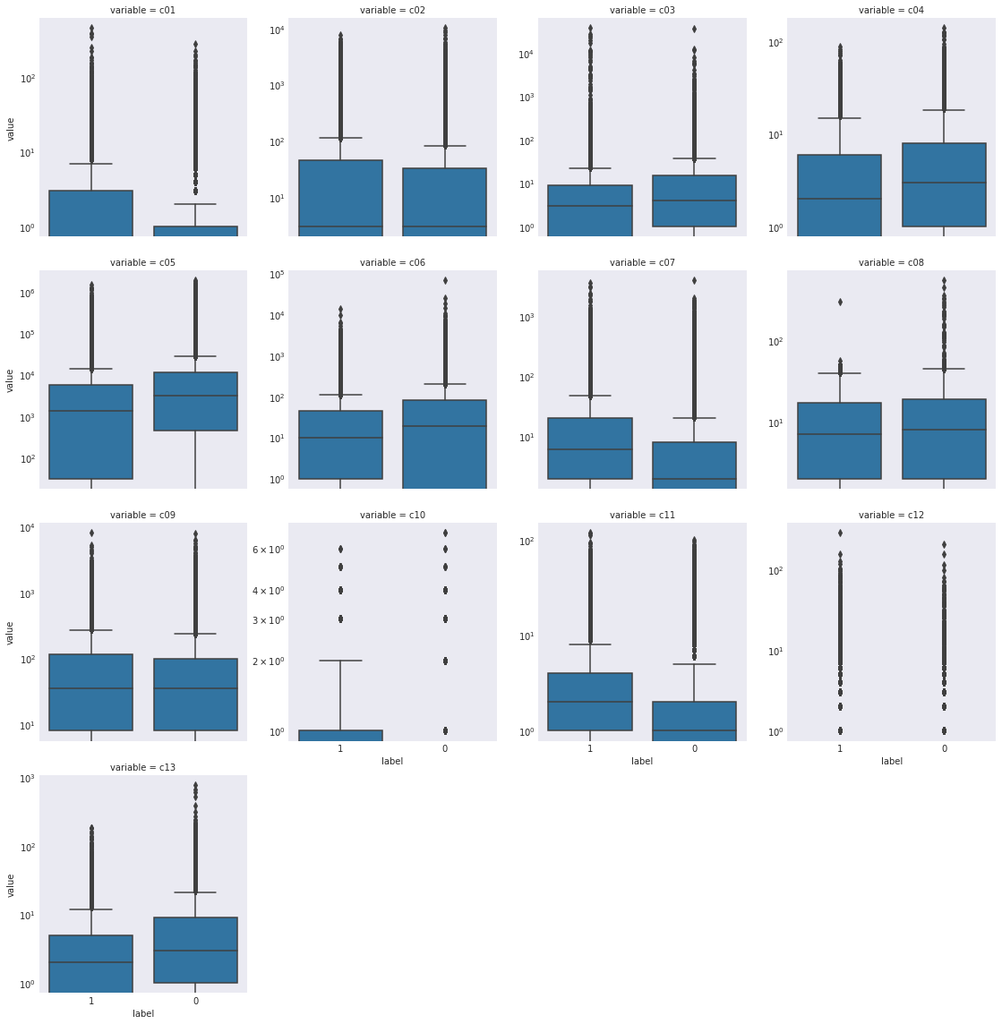

```python
# plot separation
sample_df_pd_melt = pd.melt(sample_df_pd.loc[:, numeric_features + ['label']],
                            id_vars='label', value_vars=numeric_features)
g = sns.FacetGrid(sample_df_pd_melt, col="variable", col_wrap=4, height=4, sharex=True, sharey=False)
g.map(sns.boxplot, "label", "value", order = [1,0]).set(yscale = 'log')
```

- The third thing we explored for the numerical features is the correlation: both with the labels to get a sense of relationship, and amongst themselves on the look out for multi-colinearity.

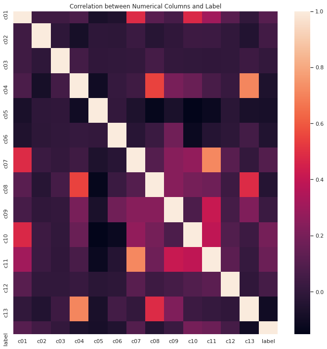

```python
# plot correlation
sns.set(rc={'figure.figsize':(12, 12)})
g = sns.heatmap(corr)
g.set_title('Correlation between Numerical Columns and Label')
```

- And finally, we tried to use some scatter plot searching for obvious relationship, yet given the range of data we don't think we see anything too obvious.

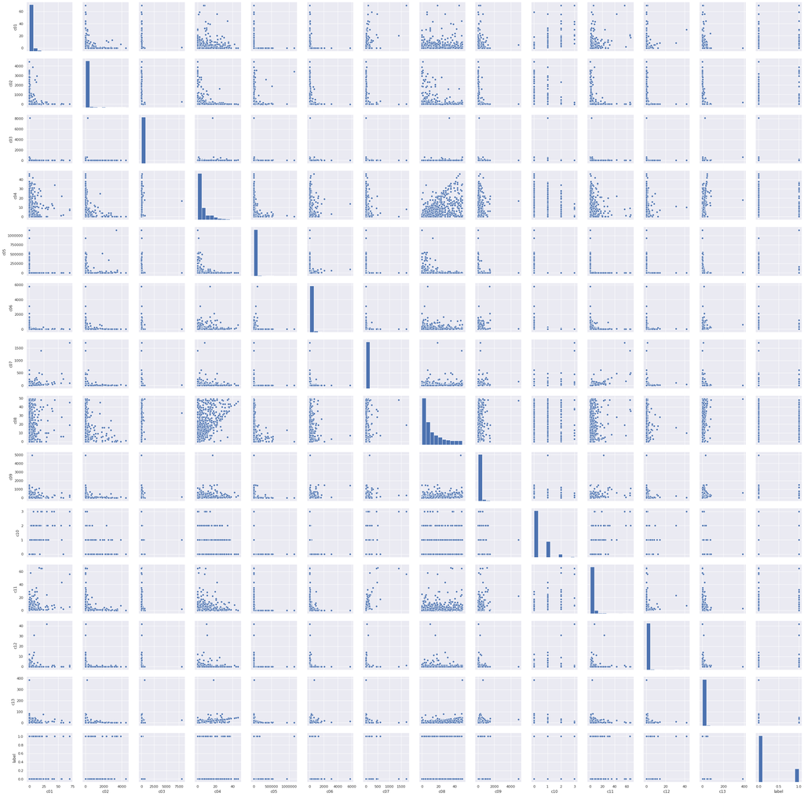

```python
sns.pairplot(sample_df_pd.sample(n=1000, random_state=1).loc[:, numeric_features + ['label']])
```

## Discussion of Challenges

There are unique challenges to this problem:

- The sheer size of the data makes it unsuitable for the typical tools people use for modeling, such as Pandas and SKlearn, which is why we choose to do it with Spark MLlib.
- The complexity of the features space would normally require a lot of domain knowledge, yet here the data is presented anonymously. Therefore, the research presented in this notebook will be based on statistical observations and practices.
- While researching into the problem, our team also keeps in mind the needs of real-time production. And that's why we have built Spark pipelines for the data, and depending on the business needs, we could efficiently deploy the code for updates/retrain of the model.

# Build Toy Models for Sampled Data

We developed two separate pipelines based on how the categorical features are treated:

- Numericals + Categoricals

  This is the more typical pipeline people use, where the categoricals are one-hot encoded and numericals are scaled
- Breiman's method

  The categoricals are replaced with their respective average labels, and hence transformed into numericals.

This section is organized in the following logic:

- Evaluation metrics
- Numerical + Categorical
  1. Build pipeline + Train/Test split
  2. Decision Tree
  3. Logistic Regression
  4. Gradient Boosted Tree
- Breiman's Method
  1. Logistic Regression
  2. Gradient Boosted Tree

## Evaluation Metrics

The are two major aspects of any classification algorithm:

- how accurate the prediction is
- how good the probability distributions are

Based on this, there are two metrics that we focus on in this study:

- f1-score: it is the harmonic mean of precision and recall, which presents a balanced view of how good the prediction is
  - Even though the event we are predicting is not extremely imbalanced like credit card default, f1-score still tells us more than simply the accuracy ratio.
  - For the f-1 score, we have built our custom function, since the one in Spark only seems to work for multi-class classfication.
- Log loss: this is the objective function in Logistic Regression, which is an good indicator of the distribution of the predicted probabilities.
  - There is no standard implementation of log loss in Spark MLlib, therefore we built our own, which takes input as `model.transform()`.

We believe the combination of the f1 score and log loss already will give us a 360-degree view of how the model is performing. The intricate trade-offs between the two are detailed in the later sessions.

In the code we also reported the AUC, because it is easy to implement.

## Categorical + Numerics

### Build pipeline + Train/Test Split

- Categorical Features
  - We're imputing the empty categorical features with its own column name with "empty", otherwise the empty strings will throw error since column names can't be empty
  - For categories that represent less than 1 percent of the sample, we are encoding them with `_less_than_1pc` before the one-hot encoding. This drastically reduces the final feature space, as shown in the EDA

```python
from pyspark.sql.functions import col, when, log, udf, log1p
def impute_blank(x):
    if x in ['b03', 'b03', 'b12', 'b16', 'b21', 'b24']:
        impute = 'empty_1'
    elif x in ['b19', 'b20', 'b25', 'b26']:
        impute = 'empty_2'
    else:
        impute = 'empty_0'

    return when(col(x) != "", col(x)).otherwise(impute)

def impute_1pc(x, less_than_1pc):
    return when(col(x).isin(list(larger_than_1pc)[0]), col(x)).otherwise('less_than_1pc')

for c in categorical_features_select:
    # every categorical feature:
    # 1) replace empty string with 'empty'
    # 2) replace categories with less than 1pc with a string
    larger_than_1pc = features_summary.larger_than_1pc[features_summary.name == c]
    sample_df = sample_df.withColumn(c, impute_blank(c))\
                         .withColumn(c, impute_1pc(c, larger_than_1pc))
```

- Numerical Features For numerical columns, we are using `log1p` transformation, and then putting them through a standard scaler why each observation is de-meaned and devided by standard deviation.

```python
def log_transformation(x):
    return when(col(x) < 0, col(x)).otherwise(log1p(col(x)))

for n in numeric_features:
    # log1p on all numerical features
    # same for train and test
    sample_df = sample_df.withColumn(n, log_transformation(n))
```

- Pipeline
  - The categorical features are first indexed, and then one-hot encoded
  - the numerical features, given that they are already in the log space, are taken as they are
  - the scaler is applied to the feature space, with `selected_features` as the final features for modeling.
  - originally, we also had the chi-squared selector in the pipeline which filters the features by looking at their relationship with the label. Yet, the features coming out of the selector didn't go with models such as SVM or random forest. On the other hand, it also did not significantly improve the performance of models like logitic regression. As a result, we decided to leave it out.

After the pipeline, we have 202 features in total, which is a reasonable number given that we have about 50 million observations in the dataset.

```python
from pyspark.ml import Pipeline
pipeline = Pipeline(stages = stages)
pipelineModel = pipeline.fit(sample_df)
sample_df_pipe = pipelineModel.transform(sample_df)
selectedCols = ['label', 'selected_features'] #+ cols
sample_df_pipe = sample_df_pipe.select(selectedCols)
sample_df_pipe.printSchema()
```

```
root
 |-- label: long (nullable = true)
 |-- selected_features: vector (nullable = true)
```

After the pipeline we have 202 features, which is equal to number of unique categories (189) plus the number of numeric features (13).

We didn't drop the last category of each column because the 1 hot encoded features are also put through the standard scaler, which frees us from the concerns of multi-colinearity.

```python
# number of features after pipeline
len(sample_df_pipe.select('selected_features').take(1)[0][0])
```

```
202
```

```python
# total number of unique categories
features_summary['# unique after'].sum()
```

```
189
```

```python
# sanity check
189 + 13
```

```
202
```

**Train/Test Split**

- Given the metrics, we are splitting the sampled set with 100k observations further into training and testing set.
- The same procedure is done once again on the full training set, since the original test set didn't come with labels.

```python
train, test = sample_df_pipe.randomSplit([0.7, 0.3], seed = 2018)
print("Training Dataset Count: " + str(train.count()))
print("Test Dataset Count: " + str(test.count()))
```

```
Training Dataset Count: 70044
Test Dataset Count: 30041
```

### Decision Tree Classifier

- Decision tree classifier with cross validation
- Feature importance and trimming
- Decision tree classifier with cross validation and sliced features

#### Decision Tree Classifier with Cross Validation

For hyper-parameter tuning, the team sets the paramGrid to test various options in the cross validation of decision tree.

- maxBins: The default setting is 32 bins, but the study also tries 16 bins to add penalization. We stop at 32 bins to avoid over-fitting.
- maxDepth: The team tests 2, 4, 6, 8 depth and stops at 8 to avoid over-fitting.
- impurity: The team uses both gini and entropy to understand information gain

```python
%%time
from pyspark.ml.classification import DecisionTreeClassifier
from pyspark.ml.tuning import ParamGridBuilder, CrossValidator
from pyspark.ml.evaluation import BinaryClassificationEvaluator

dt = DecisionTreeClassifier(featuresCol = 'selected_features', labelCol = 'label',
                            maxDepth = 5, seed = 8888)
paramGrid = ParamGridBuilder()\
             .addGrid(dt.maxDepth, [2, 4, 6, 8])\
             .addGrid(dt.impurity, ['gini', 'entropy'])\
             .addGrid(dt.maxBins, [16, 32])\
             .build()
ev = BinaryClassificationEvaluator(metricName='areaUnderROC')
cv = CrossValidator(estimator=dt,
                    estimatorParamMaps=paramGrid,
                    evaluator=ev,
                    numFolds=3, seed = 8888)

cvModel = cv.fit(train)
dtModel = cvModel.bestModel
```

```
CPU times: user 1.65 s, sys: 770 ms, total: 2.42 s
Wall time: 2min 44s
```

```python
bestBins = cvModel.bestModel._java_obj.getMaxBins()
bestDepth = cvModel.bestModel._java_obj.getMaxDepth()
bestImpurity = cvModel.bestModel._java_obj.getImpurity()
print('The best decision tree model has', bestDepth, 'layers,', bestBins,
      'bins and using', bestImpurity, 'as impurity measure.')
```

```
The best decision tree model has 6 layers, 32 bins and using entropy as impurity measure.
```

```python
eval_dt_cv = eval(cvModel, train, test, 'DT+CV')
```

```
Model: DT+CV
    Name   Data       ROC   LogLoss  F1-Score
0  DT+CV  Train  0.512806  0.512041  0.282334
1  DT+CV   Test  0.518036  0.529752  0.262007
```

The scores between train and test vary a bit, indicating that we might be over-fitting. It is a well-known disadvantage for Decision Tree, yet we started with this algorithm because we can easily calculate the feature importance based on gini index and use that for further features selection.

#### Feature Importance and Trimming

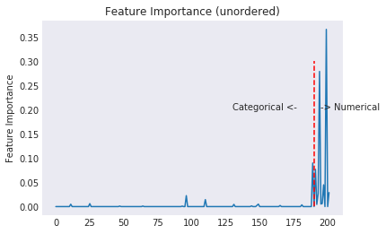

```python
# plot out the feature importance
plt.plot(featureImportancePD.feature, featureImportancePD.importance)
plt.plot(np.repeat(202 - 13 + 1, 100), np.linspace(0, .3, 100),  'r', ls = '--')
plt.ylabel('Feature Importance')
plt.title('Feature Importance (unordered)')
plt.text(130, .2, 'Categorical <-')
plt.text(195, .2, '-> Numerical')
plt.show()
```

- There are 23 features (out of 202) that are shown to be "important". If we were to further trim down the features space, wonder what that will do to the performance. The intuition there is that the less features we have, the more "regular" the loss surface will be and the less likely we are to overfit.

```python
from pyspark.ml.feature import VectorSlicer
slicer = VectorSlicer(inputCol="selected_features", outputCol="sliced_features", indices=features_lt0)
train_sliced = slicer.transform(train)
test_sliced = slicer.transform(test)
train_sliced.show(5)
```

```
+-----+--------------------+--------------------+
|label|   selected_features|     sliced_features|
+-----+--------------------+--------------------+
|    0|[-1.0016849885468...|[-0.3580504012046...|
|    0|[-1.0016849885468...|[-0.3580504012046...|
|    0|[-1.0016849885468...|[-0.3580504012046...|
|    0|[-1.0016849885468...|[-0.3580504012046...|
|    0|[-1.0016849885468...|[-0.3580504012046...|
+-----+--------------------+--------------------+
only showing top 5 rows
```

#### Decision Tree Classifier with Cross Validation and Sliced Features

```python
eval_dt_sliced_cv = eval(cvModel, train_sliced, test_sliced, name = 'DT+CV+S')
```

```
Model: DT+CV+S
      Name   Data       ROC   LogLoss  F1-Score
0  DT+CV+S  Train  0.515661  0.522705  0.303729
1  DT+CV+S   Test  0.517672  0.529677  0.294018
```

The Decision Tree model will be a baseline model for us. Given the winning score log loss is .47 and this model is showing .53, it shows us that we are at least on the right track.

### Logistic Regression

- Logistic regression with default parameters
- Logistic regression with parameter tuning
- Logistic regression with parameter tuning and sliced features

#### Logistic Regression with Default Parameters

```python
eval_lr = eval(lrModel, train, test, 'LR')
```

```
Model: LR
  Name   Data       ROC   LogLoss  F1-Score
0   LR  Train  0.738119  0.498950  0.338664
1   LR   Test  0.730594  0.504101  0.335685
```

```
Text(0.5,1,'Training Loss')
```

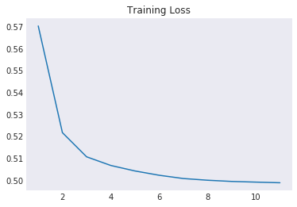

```python
# plot out training loss
g = sns.lineplot(x=range(1, len(trainingSummary.objectiveHistory) + 1),
                 y=trainingSummary.objectiveHistory)
g.set_title('Training Loss')
```

- There are 202 features in the logistic regression model (not including the intercept). Since the features are all normalized, the size of the coefficients should be a comparable scale. We see kind of a similar picture here as the feature importance chart shown from Decision Tree, yet categorical features seem to play a bigger role in this model.

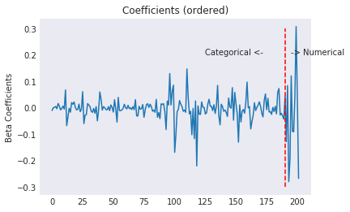

```python
# plot out the coefs
beta = (lrModel.coefficients)
plt.plot(beta)
plt.plot(np.repeat(202-13+1, 100), np.linspace(-.3, 0.3, 100),  'r', ls = '--')
plt.ylabel('Beta Coefficients')
plt.title('Coefficients (ordered)')
plt.text(125, .2, 'Categorical <-')
plt.text(195, .2, '-> Numerical')
plt.show()
```

#### Logistic Regression with Parameter Tuning

Here I'm maining tuning the `elasticNetParam` and `regParam`, which corresponds $\alpha$ and $\lambda$ in the following equation respectively $$L + \lambda[(1-\alpha)\sum\beta^2 + \alpha\sum|\beta|]$$

- when `elasticNetParam` is 0, it is purely l2 penalty; when it is 1, it is purely l1 penalty. Otherwise it is the weight between the 2. The choice here are 0, 0.5 and 1.
- `regParam` is the sererity of the penalty, here we are incrementing it on log-scale. The sum of squared coefficients from the base model is .76, which is comparable to the loss. To add in regularization but not overwhelming the training, here the choices are 0.001, 0.002, 0.005 and 0.01.

```python
%%time
lr = LogisticRegression(featuresCol = 'selected_features', labelCol = 'label',
                        maxIter=10, regParam=0, elasticNetParam=0)

# Create 3-fold CrossValidator
evaluator = BinaryClassificationEvaluator()
paramGrid = ParamGridBuilder()\
    .addGrid(lr.elasticNetParam,[0.0, 0.5, 1.0])\
    .addGrid(lr.maxIter,[10, 50, 100])\
    .addGrid(lr.regParam,[0.001, 0.002, 0.005, 0.01]) \
    .build()
cv = CrossValidator(estimator = lr, estimatorParamMaps = paramGrid,
                    evaluator = evaluator, numFolds=3, seed = 8888)

# Run cross validations
cvModel = cv.fit(train)

best_alpha = cvModel.bestModel._java_obj.getElasticNetParam()
best_lambda = cvModel.bestModel._java_obj.getRegParam()
print('Best elasticNetParam is', best_alpha)
print('Best regParam is', best_lambda)
```

```
Best elasticNetParam is 0.5
Best regParam is 0.001
CPU times: user 5.7 s, sys: 2.95 s, total: 8.65 s
Wall time: 20min 5s
```

```python
eval_lr_cv = eval(cvModel, train, test, 'LR+CV')
```

```
Model: LR+CV
    Name   Data       ROC   LogLoss  F1-Score
0  LR+CV  Train  0.738823  0.498517  0.333954
1  LR+CV   Test  0.731641  0.503432  0.332678
```

#### Sliced features on Linear Regression

```python
eval_lr_cv_sliced = eval(cvModel, train_sliced, test_sliced, 'LR+CV+S')
```

```
Model: LR+CV+S
      Name   Data       ROC   LogLoss  F1-Score
0  LR+CV+S  Train  0.713115  0.514463  0.276960
1  LR+CV+S   Test  0.707870  0.517995  0.277437
```

The sliced features don't seem to improving the performance here. We think it is because when we reduce the features space from 202 to 23, the information loss outweighs the supposed gain in parsimony. We expect this to be more dramatic when applied to the full dataset.

### Gradient Boosted Trees

#### Gradient boosted trees with default parameters

```python
from pyspark.ml.classification import GBTClassifier
gb = GBTClassifier(featuresCol = 'selected_features', labelCol = 'label',
                   maxIter = 20, seed = 8888)
gbModel = gb.fit(train)
eval_gbt = eval(gbModel, train, test, 'GBT')
```

```
Model: GBT
  Name   Data       ROC   LogLoss  F1-Score
0  GBT  Train  0.743022  0.497953  0.340222
1  GBT   Test  0.720755  0.511109  0.315513
```

#### Gradient boosted trees with parameter tuning

The parameters we tuned here are:

- maxDepth: the gradient boosted tree usually performs quite well with depth larger than 10, yet the it would also tend to overfit. Therefore the choices stopped at 10
- maxBins: the default is 32, we also tried 16 but didn't go higher.
- maxIter: the GBT in spark runs very slow and consumes a lot of memory. We weren't able to go further than 20, given the choices on the other parameters.

```python
print('Best maxDepth is', best_maxDepth)
print('Best maxBins is', best_maxBins)
print('Best maxIter is', best_maxIter)
eval_gbt_cv = eval(cvModel, train, test, 'GBT+CV')
```

```
Best maxDepth is 6
Best maxBins is 32
Best maxIter is 10
Model: GBT+CV
     Name   Data       ROC   LogLoss  F1-Score
0  GBT+CV  Train  0.743550  0.498562  0.320988
1  GBT+CV   Test  0.716025  0.514783  0.291030
CPU times: user 4.15 s, sys: 4.04 s, total: 8.19 s
Wall time: 13min 41s
```

### Summary for Categorical + Numerics

From the summary stats below, we recommend training both logistic regression and logistic regression for the full data set.

```python
eval_all = eval_dt_cv.append([eval_dt_sliced_cv, eval_lr, eval_lr_cv,
                              eval_lr_cv_sliced, eval_gbt, eval_gbt_cv])
eval_all
```

|  | Name | Data | ROC | LogLoss | F1-Score |
| --- | --- | --- | --- | --- | --- |
| 0 | DT+CV | Train | 0.512806 | 0.512041 | 0.282334 |
| 1 | DT+CV | Test | 0.518036 | 0.529752 | 0.262007 |
| 0 | DT+CV+S | Train | 0.515661 | 0.522705 | 0.303729 |
| 1 | DT+CV+S | Test | 0.517672 | 0.529677 | 0.294018 |
| 0 | LR | Train | 0.738119 | 0.498950 | 0.338664 |
| 1 | LR | Test | 0.730594 | 0.504101 | 0.335685 |
| 0 | LR+CV | Train | 0.738823 | 0.498517 | 0.333954 |
| 1 | LR+CV | Test | 0.731641 | 0.503432 | 0.332678 |
| 0 | LR+CV+S | Train | 0.713115 | 0.514463 | 0.276960 |
| 1 | LR+CV+S | Test | 0.707870 | 0.517995 | 0.277437 |
| 0 | GBT | Train | 0.743022 | 0.497953 | 0.340222 |
| 1 | GBT | Test | 0.720755 | 0.511109 | 0.315513 |
| 0 | GBT+CV | Train | 0.743550 | 0.498562 | 0.320988 |
| 1 | GBT+CV | Test | 0.716025 | 0.514783 | 0.291030 |

## Breiman's Method

Here we are implementing Breiman's data transformation: replacing the categorical data with the average of labels. This allows us to convert categoricals to numerics, which reduces the features space. There are two versions of this method that we implemented:

1. Data transformation with imputed features:

   As discussed in the EDA, the categories are highly skewed. As a result, we propose to impute the categories that shows up less than 1 percent of the sample with string "less_than_1pc" before group by the categories and calculate the mean of each imputed category.
2. Data transformation without imputing features: using the raw categories as they are.

After implementing both versions, we see that the second version is grossly overfitting the data. Therefore we archived that version in the appendix, and highlight version 1 in this report in the following three sections:

- Data Transformation
- Logistic Regression
- Gradient Boosted Tree

### Data Transformation

```python
%%time
from pyspark.sql.functions import broadcast

for c in categorical_features:
    print(c)
    # get the categorical means
    means = train_bm.groupBy(c).agg({'label':'mean'})
    means = means.withColumnRenamed('avg(label)', c+'_bm')
    means = means.withColumnRenamed(c, 'r')

    # left join to train
    train_bm = train_bm.withColumnRenamed(c, 'l')
    train_bm.repartition('l')
    train_bm = train_bm.join(broadcast(means), train_bm.l == means.r, how = 'left').drop('l').drop('r')

    # left join to test
    test_bm = test_bm.withColumnRenamed(c, 'l')
    test_bm.repartition('l')
    test_bm = test_bm.join(broadcast(means), test_bm.l == means.r, how = 'left').drop('l').drop('r')

    # force it to repartition every 5 joins, otherwise the joining take FOREVER
    if c in ['b05', 'b10', 'b15', 'b20', 'b26']:
        print('repartition')
        train_bm.write.parquet("full_data/temp/trainbm.parquet" + c)
        test_bm.write.parquet("full_data/temp/testbm.parquet"+ c)
        train_bm = spark.read.parquet("full_data/temp/trainbm.parquet"+ c)
        test_bm = spark.read.parquet("full_data/temp/testbm.parquet"+ c)

test_bm = test_bm.na.fill(0)
```

```
b01
b02
b03
b04
b05
repartition
b06
b07
b08
b09
b10
repartition
b11
b12
b13
b14
b15
repartition
b16
b17
b18
b19
b20
repartition
b21
b22
b23
b24
b25
b26
repartition
CPU times: user 420 ms, sys: 340 ms, total: 760 ms
Wall time: 1min 25s
```

### Logistic Regression with Breiman's method

```python
eval_lr_bm = eval(lrModel, train, test, 'LR+BM')
```

```
Model: LR+BM
    Name   Data       ROC   LogLoss  F1-Score
0  LR+BM  Train  0.728219  0.504692  0.312716
1  LR+BM   Test  0.726216  0.508085  0.314968
```

We got similar (slightly higher) loss rate than the logistic regression in the other pipeline, which shows:

1. Breiman's method is an efficient way to deal with categorical variables, especially if the number of unique categories are so big that one-hot encoding it is not feasible.
2. The loss is still higher because Breiman's method all introduces information loss. Consider a feature with 100 observations divided 25 and 75: data will still show variations if one-hot encoded (0s and 1s), but they will be the same after Breiman's transformation.

### Gradient Boosted Trees with Breiman's Method

```python
from pyspark.ml.classification import GBTClassifier
gb = GBTClassifier(featuresCol = 'selected_features', labelCol = 'label',
                   maxIter = 20, seed = 8888)
gbModel = gb.fit(train)
eval_gbt_bm = eval(gbModel, train, test, 'GBT+BM')
```

```
Model: GBT+BM
     Name   Data       ROC   LogLoss  F1-Score
0  GBT+BM  Train  0.744219  0.496481  0.327607
1  GBT+BM   Test  0.727692  0.508713  0.315204
```

### Summary for Breiman's Method

GBT here showed similar results. Since the logistic regression will be more explainable, we chose to only run logistic regression when fitting the full data through Breiman's transformation in the next section.

```python
eval_all_BM = eval_lr_bm.append([eval_gbt_bm, eval_lr_bm_raw, eval_gbt_bm_raw])
eval_all_BM
```

|  | Name | Data | ROC | LogLoss | F1-Score |
| --- | --- | --- | --- | --- | --- |
| 0 | LR+BM | Train | 0.728219 | 0.504692 | 0.312716 |
| 1 | LR+BM | Test | 0.726216 | 0.508085 | 0.314968 |
| 0 | GBT+BM | Train | 0.744219 | 0.496481 | 0.327607 |
| 1 | GBT+BM | Test | 0.727692 | 0.508713 | 0.315204 |
| 0 | LR+BM Raw | Train | 0.962717 | 0.208049 | 0.812294 |
| 1 | LR+BM Raw | Test | 0.617494 | 0.902251 | 0.263471 |
| 0 | GBT+BM Raw | Train | 0.966866 | 0.219323 | 0.810052 |
| 1 | GBT+BM Raw | Test | 0.531103 | 0.727883 | 0.260219 |

# Model with Full Data

- Categorical + Numerical
  - Logistic regression
  - Gradient boosted trees
- Breiman's Method
  - Logistic regression

## Categorical + Numerical

```python
import time
start = time.time()
!python3 submit_job_to_cluster.py \
    --project_id=w261-256321 \
    --zone=us-west2-b \
    --cluster_name=final-project \
    --gcs_bucket=261_bucket_zengm71 \
    --key_file=$HOME/w261.json \
    --worker_nodes=15 \
    --create_new_cluster \
    --pyspark_file=full_data_lr.py
print(f'... completed job in {time.time() - start} seconds.')
```

```
Creating cluster...
Waiting for cluster creation...
Cluster created.
Uploading pyspark file to GCS
final-project - RUNNING
Submitted job ID f621583e-1c5a-4b0a-b417-670270e0315f
Waiting for job to finish...
Job finished.
Downloading output file
b'====== Training Dataset Count: 32089468'
b'====== Test Dataset Count: 13751149'
b'====== Logistic Regression ========================================'
b'====== Train Area Under ROC 0.7355051192582652'
b'====== Train Log Loss:  [Row(avg(log_loss)=0.4994656972474252)]'
b'====== Train F1 Score:  0.32399346059737827'
b'====== Test Area Under ROC 0.7353038324506003'
b'====== Test Log Loss:  [Row(avg(log_loss)=0.49963011166872723)]'
b'====== Test F1 Score:  0.32409527565021723'
Tearing down cluster
... completed job in 2049.138465166092 seconds.
```

```python
# GBT with 50 iterations
import time
start = time.time()
!python3 submit_job_to_cluster.py \
    --project_id=w261-256321 \
    --zone=us-west2-b \
    --cluster_name=final-project \
    --gcs_bucket=261_bucket_zengm71 \
    --key_file=$HOME/w261.json \
    --worker_nodes=23 \
    --create_new_cluster \
    --pyspark_file=full_data_gbt.py
print(f'... completed job in {time.time() - start} seconds.')
```

```
Creating cluster...
Waiting for cluster creation...
Cluster created.
Uploading pyspark file to GCS
final-project - RUNNING
Submitted job ID 6c9db092-6055-45e8-8a22-5c588f8c997f
Waiting for job to finish...
Job finished.
Downloading output file
b'====== Training Dataset Count: 32089468'
b'====== Test Dataset Count: 13751102'
b'====== Gradient Boosted Tress ========================================'
b'====== Train Area Under ROC 0.7399972672247248'
b'====== Train Log Loss:  [Row(avg(log_loss)=0.49682252147163386)]'
b'====== Train F1 Score:  0.3456295596321672'
b'====== Test Area Under ROC 0.7398007452800197'
b'====== Test Log Loss:  [Row(avg(log_loss)=0.4969489017311084)]'
b'====== Test F1 Score:  0.34557869909700195'
Tearing down cluster
... completed job in 3318.4152722358704 seconds.
```

## Breiman's Method

```python
import time
start = time.time()
!python3 submit_job_to_cluster.py \
    --project_id=w261-256321 \
    --zone=us-west2-b \
    --cluster_name=final-project-bm \
    --gcs_bucket=261_bucket_zengm71 \
    --key_file=$HOME/w261.json \
    --worker_nodes=23 \
    --create_new_cluster \
    --pyspark_file=full_data_bm.py
print(f'... completed job in {time.time() - start} seconds.')
```

```
Creating cluster...
Waiting for cluster creation...
Cluster created.
Uploading pyspark file to GCS
final-project-bm - RUNNING
Submitted job ID a815dd63-4089-48ca-bddd-8266b895e374
Waiting for job to finish...
Job finished.
Downloading output file
b'====== Training Dataset Count: 32090809'
b'====== Training Dataset Features Count 39'
b'====== Test Dataset Count: 13749808'
b'====== Logistic Regression ========================================'
b'====== Train Area Under ROC 0.7274902908194077'
b'====== Train Log Loss:  [Row(avg(log_loss)=0.5047032420511904)]'
b'====== Train F1 Score:  0.3063345442530332'
b'====== Test Area Under ROC 0.7272185613190802'
b'====== Test Log Loss:  [Row(avg(log_loss)=0.5046195075049039)]'
b'====== Test F1 Score:  0.30593882089018143'
Tearing down cluster
... completed job in 1510.3345432281494 seconds.
```

## Summary Stats on Full Data

We got similar results as we do on the sampled data, which shows:

1. our implementation is scalable
2. GBT when trained with more iterations makes a big difference, but it takes a lot resources on the system.

| Pipeline | Model | Train ROC | Train LogLoss | Train F1 | Test ROC | Test LogLoss | Test F1 |
| --- | --- | --- | --- | --- | --- | --- | --- |
| N+C | Logistic Regression | 0.735505 | 0.499465 | 0.323993 | 0.735304 | 0.499630 | 0.324095 |
| N+C | Gradient Boosted Trees | 0.739997 | 0.496823 | 0.345629 | 0.739801 | 0.496949 | 0.345579 |
| Breiman | Logistic Regression | 0.727490 | 0.504703 | 0.306334 | 0.727218 | 0.504619 | 0.305939 |

# Application of Course Concepts

- Decision Tree

As we learned in class, decision tree has quite flexible usage. It can return good prediction with a mixture of data types and minimum data cleansing. At the same time, it can be used for feature selection or as a classification model. In this study, the team uses the decision tree to find the feature importance, and picks inputs based on a threshold. Since the input data contains many one hot encoding categorical features, this feature selection reduces the input dimension. It helps making the model more parsimonious but it also introduces loss of information.

- Breiman’s Theorem

With many categorical features, the team tries to use Breiman's theorem as an alternative to one hot encoding. The trials include replacing the values of the categorical features with the average values of the labels.

- Spark Pipeline

The team builds the feature engineering and model training steps in a MLLib pipeline, which not only helps to ease communication for process development among the team, but also increases the scalability of the model. We use the provided functions such as standard scaler, assembler, string indexer, one-hot encoder and vector slicer.

- Logistic Regression under Map Reduce paradigm

A toy example is presented where we implemented gradient descent with logistic regression as a proof-of-concept.

# Next Steps

- The study only explores a few regularization and tuning opportunities on the 100,000 samples. The team doesn’t see much enhancement from the result; therefore decides not to implement in the full dataset. However, there can be additional improvement with more focus on the hyper parameter tuning.
- Many research papers indicate advanced models, such as Field-Aware Factorization Machine (FFM), and a combination of decision tree and logistics regression that have shown to return better accuracy in the literature. Further study can test on implementing the scalable version of the advanced models in the Spark environment.

# Reference

Code documentation:

- https://spark.apache.org/docs/latest/ml-guide.html

Notebooks:

- http://restanalytics.com/2019-03-11-Distributed-Machine-Learing-with-Spark-ML/
- https://docs.databricks.com/_static/notebooks/binary-classification.html

Papers & Articles:

- https://medium.com/@jason9389/gini-impurity-and-entropy-16116e754b27
- https://arxiv.org/pdf/1711.01377.pdf
- https://arxiv.org/pdf/1701.04099.pdf
- https://research.fb.com/publications/practical-lessons-from-predicting-clicks-on-ads-at-facebook/
- https://www.dropbox.com/s/s4x7wp8gjsh021d/TISTRespPredAds-Chappelle-CTR-Prediction-2014Paper.pdf?dl+=0
- https://www.csie.ntu.edu.tw/~r01922136/slides/ffm.pdf
- https://www.dropbox.com/s/iozods194twg2pv/MLParis2015-excellent-Sldies.pdf?dl=0
- http://statweb.stanford.edu/~jhf/ftp/trebst.pdf
- https://www.dropbox.com/s/2n8uekjwpaur3bj/Deep-Learning-for-Criteo-Documentation.pdf?dl=0
- https://www.csie.ntu.edu.tw/~r01922136/slides/kaggle-avazu.pdf

# Appendix

Here we archived the work that we touched on but haven't drilled down due to limited time we have.

- Random forest classifier
- SVM
- Breiman's method with raw features

## Random Forest Classifier

|  | ROC | LogLoss | F-1 Score |
| --- | --- | --- | --- |
| Train | 0.713158 | 0.524612 | 0.025323 |
| Test | 0.713158 | 0.526751 | 0.329445 |

## SVM

```python
# Evaluate on Train
predictions = svmModel.transform(train)
evaluator = BinaryClassificationEvaluator()
print('Train Area Under ROC', evaluator.evaluate(predictions))
# log_loss_from_prediction(predictions)
```

```
Train Area Under ROC 0.7108954779037794
```

```python
# Make Predictions
predictions = svmModel.transform(test)
evaluator = BinaryClassificationEvaluator()
print('Test Area Under ROC', evaluator.evaluate(predictions))
# log_loss_from_prediction(predictions)
```

```
Test Area Under ROC 0.7117912150639231
```

## Breiman's method with raw features

### Data Transformation

### Logistic Regression

```python
eval_lr_bm_raw = eval(lrModel, train, test, 'LR+BM Raw')
```

```
Model: LR+BM Raw
        Name   Data       ROC   LogLoss  F1-Score
0  LR+BM Raw  Train  0.962717  0.208049  0.812294
1  LR+BM Raw   Test  0.617494  0.902251  0.263471
```